# 20-nm-C-250-nm-ZnO-Silica-15kV

John Minter

2018-08-06

# 1 Set up for the analysis

**Note**: This version used the same `MSIMPA` parameters for all layers.

First load the libraries we need…

```r
library(rpenepma)
library(dplyr)
library(pander)
library(ggplot2)
```

Next, set the paths and constants that we need… **Note**: We expect to run this script from a directory within the `monte-carlo-simulations` git project folder (cloned from [here](https://github.com/jrminter/monte-carlo-simulations)) and expect that to be in the user’s `git` directory, the path of which is stored in the `GIT_HOME` environment variable.

```r
e0         <- 15 # kV
int_lo_lim <- 1.0e-1
int_hi_lim <- 1.0e4
git_home   <- Sys.getenv('GIT_HOME')
rel_dir    <- "monte-carlo-simulations/penepma/penepma16"
sim_nam    <- "20-nm-C-250-nm-ZnO-Silica"
sim_dir    <- sprintf("%s/%s/%s-%gkV", git_home, rel_dir, sim_nam, e0)

res_fi  <- "./penepma-res.dat"
int_fi  <- "./pe-intens-01.dat"
spc_fi  <- "./pe-spect-01.dat"
out_ti  <- sprintf("%s-%gkV", sim_nam, e0)
msa_fi  <- sprintf("./%s-%gkV.msa", sim_nam, e0)
# print(getwd())
# wd <- sprintf("%s/%s", sim_dir, sim_nam)
```

# 2 Retrieve the number of showers

We want retrieve the number of showers (trajectories) that our `penepma16` simulation calculated.

```r
options(scipen = -6) # force printing in exponetial format
num_showers <- penepma_get_number_of_showers(res_fi)
cat(num_showers)
```

```
3.09446e+05
```

```r
options(scipen = 3) # reset to default
```

# 3 Compute the total maximum intensity for each element

## 3.1 Retrieve the data

First retrieve the intensity data as a `tibble` and print a preview.

```r
tib <- penepma_get_intensities(int_fi)
print(tib)
```

```
# A tibble: 23 x 14
      IZ S0    S1      keV    P.mu    P.se    C.mu    C.se     B.mu
   <int> <fct> <fct> <dbl>   <dbl>   <dbl>   <dbl>   <dbl>    <dbl>
 1     6 K     L2    0.277 9.25e-7 7.76e-7 1.63e-9 4.89e-9 2.56e-10
 2     6 K     L3    0.277 1.31e-6 9.23e-7 1.63e-9 4.89e-9 7.68e-10
 3     8 K     L2    0.525 2.05e-5 1.88e-5 3.75e-8 5.20e-8 8.44e- 9
 4     8 K     L3    0.525 3.01e-5 1.88e-5 5.38e-8 2.81e-8 1.02e- 8
 5    30 L3    M1    0.884 2.78e-5 2.03e-6 2.61e-8 1.96e-8 2.21e- 8
 6    30 L2    M1    0.906 1.40e-5 1.43e-6 1.63e-9 4.89e-9 1.13e- 8
 7    30 L3    M2    0.932 6.53e-8 9.79e-8 0.      0.      0.
 8    30 L3    M3    0.934 4.89e-8 8.48e-8 0.      0.      0.
 9    30 L2    M3    0.957 6.53e-8 9.79e-8 0.      0.      0.
10    30 L3    M5    1.01  3.70e-5 2.33e-6 4.01e-7 1.08e-6 2.88e- 8
# ... with 13 more rows, and 5 more variables: B.se <dbl>, TF.mu <dbl>,
#   TF.se <dbl>, Int.mu <dbl>, Int.se <dbl>
```

What features did we measure?

```r
print(names(tib))
```

```
 [1] "IZ"     "S0"     "S1"     "keV"    "P.mu"   "P.se"   "C.mu"
 [8] "C.se"   "B.mu"   "B.se"   "TF.mu"  "TF.se"  "Int.mu" "Int.se"
```

How many transitions did we measure?

```r
print(nrow(tib))
```

```
[1] 23
```

## 3.2 Compute the maximum total intensity for each element

1. Compute the maximum total intensity for each element.
2. Stack each row of data together into a tibble.
3. Prepend the sample ID to the data.
4. Print a well-formatted a table using `pander`.
5. Save the final tibble so it can be r-loaded later

```r
# 1
C_t   <- penepma_get_max_total_intensity_z(tib, 6)
O_t   <- penepma_get_max_total_intensity_z(tib, 8)
Zn_t  <- penepma_get_max_total_intensity_z(tib, 30)
Si_t  <- penepma_get_max_total_intensity_z(tib, 14)
# 2
tot_int <- dplyr::bind_rows(C_t, O_t, Zn_t, Si_t)
#3
C_20_nm_ZnO_250_nm_SiO2_15kV <- prepend_sample_id_max_int_tib(tot_int, out_ti)
# 4
panderOptions('table.split.table', Inf)
pander(C_20_nm_ZnO_250_nm_SiO2_15kV)
```

| Sample.ID | Symbol | IZ | S0 | S1 | Int.mu | Int.se | Int.snr |
| --- | --- | --- | --- | --- | --- | --- | --- |
| 20-nm-C-250-nm-ZnO-Silica-15kV | C | 6 | K | L3 | 0.000001315 | 0.000000923 | 1.425 |
| 20-nm-C-250-nm-ZnO-Silica-15kV | O | 8 | K | L3 | 0.00003014 | 0.0000188 | 1.603 |
| 20-nm-C-250-nm-ZnO-Silica-15kV | Zn | 30 | L3 | M5 | 0.00003745 | 0.00000257 | 14.57 |
| 20-nm-C-250-nm-ZnO-Silica-15kV | Si | 14 | K | L3 | 0.00003255 | 0.0000324 | 1.005 |

```r
# 5
save(C_20_nm_ZnO_250_nm_SiO2_15kV, file="C_20_nm_ZnO_250_nm_SiO2_15kV.rda")
# delete and reload be sure it worked...
rm(C_20_nm_ZnO_250_nm_SiO2_15kV)
load("./C_20_nm_ZnO_250_nm_SiO2_15kV.rda")
```

# 4 Process the spectra data

## 4.1 Load the raw data

```r
tib <- penepma_read_raw_data(spc_fi,min_intensity_clip=5.0e-10)
rownames(df) <- c()
```

Examine the start:

```r
pander(head(tib))
```

| keV | mu | se |
| --- | --- | --- |
| 0.01183 | 0.5 | 0.5 |
| 0.01549 | 0.5 | 0.5 |
| 0.01915 | 0.5 | 0.5 |
| 0.02281 | 0.5 | 0.5 |
| 0.02647 | 0.5 | 0.5 |
| 0.03013 | 0.5 | 0.5 |

Examine the end:

```r
pander(tail(tib))
```

| keV | mu | se |
| --- | --- | --- |
| 14.98 | 0.5 | 0.5 |
| 14.98 | 0.5 | 0.5 |
| 14.99 | 0.5 | 0.5 |
| 14.99 | 0.5 | 0.5 |
| 14.99 | 0.5 | 0.5 |
| 15 | 0.5 | 0.5 |

## 4.2 Plot the spectrum.

There is a very large dynamic range for both the **probability density** and the **uncertainty**. Penepma sets a lower limit for data at **1.0e-35**. Missing values are set to zero. We want to remove values from the dataframe that are below a useful limit. We do this below and plot a copy of the dataframe that is limited to the useful values.

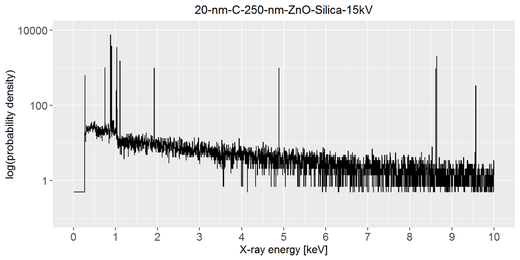

```r
plt <- ggplot(tib, aes(x = keV, y = mu)) +
       geom_line() +
       scale_x_continuous(breaks = seq(from = 0, to = e0-5, by = 1),
                          limits = c(0,e0-5)) +
       scale_y_log10(limits = c(int_lo_lim, int_hi_lim)) +
       xlab(label="X-ray energy [keV]") +
       ylab(label="log(probability density)") +
       # (1/(eV*sr*electron)") +
       ggtitle(out_ti) +
       theme(axis.text=element_text(size=12),
             axis.title=element_text(size=12),
             # center the title
             plot.title = element_text(hjust = 0.5))

print(plt)
```

And on a linear intensity scale…

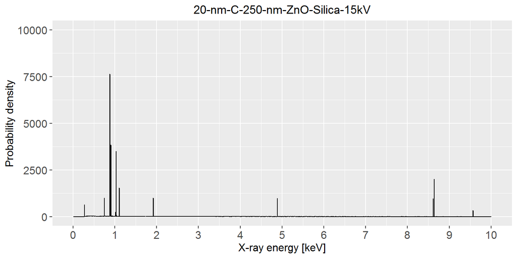

```r
plt <- ggplot(tib, aes(x = keV, y = mu)) +
       geom_line() +
       scale_x_continuous(breaks = seq(from = 0, to = e0-5, by = 1),
                          limits = c(0,e0-5)) +
       scale_y_continuous(limits = c(int_lo_lim, int_hi_lim)) +
       xlab(label="X-ray energy [keV]") +
       ylab(label="Probability density") +
       # (1/(eV*sr*electron)") +
       ggtitle(out_ti) +
       theme(axis.text=element_text(size=12),
             axis.title=element_text(size=12),
             # center the title
             plot.title = element_text(hjust = 0.5))

print(plt)
```

## 4.3 Write a spectrum file in MSA format

```r
penepma_to_msa(spc_fi, msa_fi,e0, out_ti)
```